# Risk Factor Analysis

## Outcome Variable

**Outcome Variable:** haz

## Predictor Variables

**Intervention Variable:** impsan

**Adjustment Set:**

- arm
- sex
- W_mage
- meducyrs
- feducyrs
- hhwealth_quart
- hfoodsec
- W_mhtcm
- W_mwtkg
- W_mbmi
- W_nrooms
- W_nchldlt5
- W_parity
- impfloor
- safeh20
- delta_W_mage
- delta_meducyrs
- delta_feducyrs
- delta_hhwealth_quart
- delta_hfoodsec
- delta_W_mhtcm
- delta_W_mwtkg
- delta_W_mbmi
- delta_W_nrooms
- delta_W_nchldlt5
- delta_W_parity
- delta_impfloor
- delta_safeh20

## Stratifying Variables

The analysis was stratified on these variable(s):

- agecat
- studyid
- country

## Data Summary

| agecat | studyid | country | impsan | n_cell | n | outcome_variable |
| --- | --- | --- | --- | --- | --- | --- |
| Birth | COHORTS | GUATEMALA | 1 | 45 | 491 | haz |
| Birth | COHORTS | GUATEMALA | 0 | 446 | 491 | haz |
| Birth | COHORTS | INDIA | 1 | 1767 | 4776 | haz |
| Birth | COHORTS | INDIA | 0 | 3009 | 4776 | haz |
| Birth | COHORTS | PHILIPPINES | 1 | 178 | 1191 | haz |
| Birth | COHORTS | PHILIPPINES | 0 | 1013 | 1191 | haz |
| Birth | CONTENT | PERU | 1 | 1 | 2 | haz |
| Birth | CONTENT | PERU | 0 | 1 | 2 | haz |
| Birth | JiVitA-3 | BANGLADESH | 1 | 15220 | 22431 | haz |
| Birth | JiVitA-3 | BANGLADESH | 0 | 7211 | 22431 | haz |
| Birth | JiVitA-4 | BANGLADESH | 1 | 2181 | 2820 | haz |
| Birth | JiVitA-4 | BANGLADESH | 0 | 639 | 2820 | haz |
| Birth | MAL-ED | BANGLADESH | 1 | 179 | 213 | haz |
| Birth | MAL-ED | BANGLADESH | 0 | 34 | 213 | haz |
| Birth | MAL-ED | BRAZIL | 1 | 59 | 60 | haz |
| Birth | MAL-ED | BRAZIL | 0 | 1 | 60 | haz |
| Birth | MAL-ED | INDIA | 1 | 15 | 40 | haz |
| Birth | MAL-ED | INDIA | 0 | 25 | 40 | haz |
| Birth | MAL-ED | NEPAL | 1 | 25 | 26 | haz |
| Birth | MAL-ED | NEPAL | 0 | 1 | 26 | haz |
| Birth | MAL-ED | PERU | 1 | 52 | 208 | haz |
| Birth | MAL-ED | PERU | 0 | 156 | 208 | haz |
| Birth | MAL-ED | SOUTH AFRICA | 1 | 0 | 95 | haz |
| Birth | MAL-ED | SOUTH AFRICA | 0 | 95 | 95 | haz |
| Birth | MAL-ED | TANZANIA, UNITED REPUBLIC OF | 1 | 0 | 118 | haz |
| Birth | MAL-ED | TANZANIA, UNITED REPUBLIC OF | 0 | 118 | 118 | haz |
| Birth | NIH-Birth | BANGLADESH | 1 | 231 | 608 | haz |
| Birth | NIH-Birth | BANGLADESH | 0 | 377 | 608 | haz |
| Birth | NIH-Crypto | BANGLADESH | 1 | 632 | 721 | haz |
| Birth | NIH-Crypto | BANGLADESH | 0 | 89 | 721 | haz |

[output cut: 70 more lines]

The following strata were considered:

- agecat: 24 months, studyid: COHORTS, country: GUATEMALA
- agecat: 24 months, studyid: COHORTS, country: INDIA
- agecat: 24 months, studyid: COHORTS, country: PHILIPPINES
- agecat: 24 months, studyid: CONTENT, country: PERU
- agecat: 24 months, studyid: JiVitA-3, country: BANGLADESH
- agecat: 24 months, studyid: JiVitA-4, country: BANGLADESH
- agecat: 24 months, studyid: LCNI-5, country: MALAWI
- agecat: 24 months, studyid: MAL-ED, country: BANGLADESH
- agecat: 24 months, studyid: MAL-ED, country: BRAZIL
- agecat: 24 months, studyid: MAL-ED, country: INDIA
- agecat: 24 months, studyid: MAL-ED, country: NEPAL
- agecat: 24 months, studyid: MAL-ED, country: PERU
- agecat: 24 months, studyid: MAL-ED, country: SOUTH AFRICA
- agecat: 24 months, studyid: MAL-ED, country: TANZANIA, UNITED REPUBLIC OF
- agecat: 24 months, studyid: NIH-Birth, country: BANGLADESH
- agecat: 24 months, studyid: NIH-Crypto, country: BANGLADESH
- agecat: 24 months, studyid: PROVIDE, country: BANGLADESH
- agecat: 6 months, studyid: COHORTS, country: GUATEMALA
- agecat: 6 months, studyid: COHORTS, country: INDIA
- agecat: 6 months, studyid: COHORTS, country: PHILIPPINES
- agecat: 6 months, studyid: CONTENT, country: PERU
- agecat: 6 months, studyid: JiVitA-3, country: BANGLADESH
- agecat: 6 months, studyid: JiVitA-4, country: BANGLADESH
- agecat: 6 months, studyid: LCNI-5, country: MALAWI
- agecat: 6 months, studyid: MAL-ED, country: BANGLADESH
- agecat: 6 months, studyid: MAL-ED, country: BRAZIL
- agecat: 6 months, studyid: MAL-ED, country: INDIA
- agecat: 6 months, studyid: MAL-ED, country: NEPAL
- agecat: 6 months, studyid: MAL-ED, country: PERU
- agecat: 6 months, studyid: MAL-ED, country: SOUTH AFRICA
- agecat: 6 months, studyid: MAL-ED, country: TANZANIA, UNITED REPUBLIC OF
- agecat: 6 months, studyid: NIH-Birth, country: BANGLADESH
- agecat: 6 months, studyid: NIH-Crypto, country: BANGLADESH
- agecat: 6 months, studyid: PROVIDE, country: BANGLADESH
- agecat: Birth, studyid: COHORTS, country: GUATEMALA
- agecat: Birth, studyid: COHORTS, country: INDIA
- agecat: Birth, studyid: COHORTS, country: PHILIPPINES
- agecat: Birth, studyid: CONTENT, country: PERU
- agecat: Birth, studyid: JiVitA-3, country: BANGLADESH
- agecat: Birth, studyid: JiVitA-4, country: BANGLADESH
- agecat: Birth, studyid: MAL-ED, country: BANGLADESH
- agecat: Birth, studyid: MAL-ED, country: BRAZIL
- agecat: Birth, studyid: MAL-ED, country: INDIA
- agecat: Birth, studyid: MAL-ED, country: NEPAL
- agecat: Birth, studyid: MAL-ED, country: PERU
- agecat: Birth, studyid: MAL-ED, country: SOUTH AFRICA
- agecat: Birth, studyid: MAL-ED, country: TANZANIA, UNITED REPUBLIC OF
- agecat: Birth, studyid: NIH-Birth, country: BANGLADESH
- agecat: Birth, studyid: NIH-Crypto, country: BANGLADESH
- agecat: Birth, studyid: PROVIDE, country: BANGLADESH

### Dropped Strata

Some strata were dropped due to rare outcomes:

- agecat: Birth, studyid: CONTENT, country: PERU
- agecat: Birth, studyid: MAL-ED, country: BRAZIL
- agecat: Birth, studyid: MAL-ED, country: NEPAL
- agecat: Birth, studyid: MAL-ED, country: SOUTH AFRICA
- agecat: Birth, studyid: MAL-ED, country: TANZANIA, UNITED REPUBLIC OF
- agecat: Birth, studyid: PROVIDE, country: BANGLADESH
- agecat: 6 months, studyid: LCNI-5, country: MALAWI
- agecat: 6 months, studyid: MAL-ED, country: BRAZIL
- agecat: 6 months, studyid: MAL-ED, country: NEPAL
- agecat: 6 months, studyid: MAL-ED, country: SOUTH AFRICA
- agecat: 6 months, studyid: MAL-ED, country: TANZANIA, UNITED REPUBLIC OF
- agecat: 6 months, studyid: PROVIDE, country: BANGLADESH
- agecat: 24 months, studyid: LCNI-5, country: MALAWI
- agecat: 24 months, studyid: MAL-ED, country: BRAZIL
- agecat: 24 months, studyid: MAL-ED, country: NEPAL
- agecat: 24 months, studyid: MAL-ED, country: SOUTH AFRICA
- agecat: 24 months, studyid: MAL-ED, country: TANZANIA, UNITED REPUBLIC OF
- agecat: 24 months, studyid: PROVIDE, country: BANGLADESH

## Methods Detail

We’re interested in the causal parameters $E[Y_a]$ for all values of $a \in \mathcal{A}$. These parameters represent the mean outcome if, possibly contrary to fact, we intervened to set all units to have $A=a$. Under the randomization and positivity assumptions, these are identified by the statistical parameters $\psi_a=E_W[E_{Y|A,W}(Y|A=a,W)]$. In addition, we’re interested in the mean of $Y$, $E[Y]$ under no intervention (the observed mean). We will estimate these parameters by using SuperLearner to fit the relevant likelihood factors – $E_{Y|A,W}(Y|A=a,W)$ and $p(A=a|W)$, and then updating our likelihood fit using a joint TMLE.

For unadjusted analyses ($W=\{\}$), initial likelihoods were estimated using Lrnr_glm to estimate the simple $E(Y|A)$ and Lrnr_mean to estimate $p(A)$. For adjusted analyses, a small library containing Lrnr_glmnet, Lrnr_xgboost, and Lrnr_mean was used.

Having estimated these parameters, we will then use the delta method to estimate relative risks and attributable risks relative to a prespecified baseline level of $A$.

# Results Detail

## Results Plots

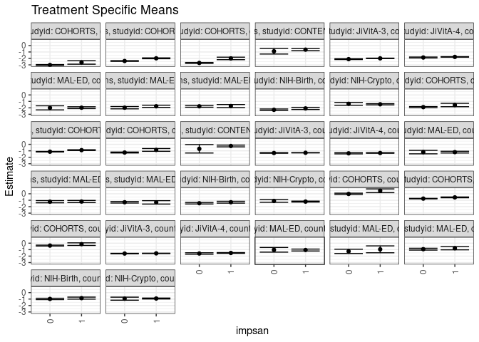

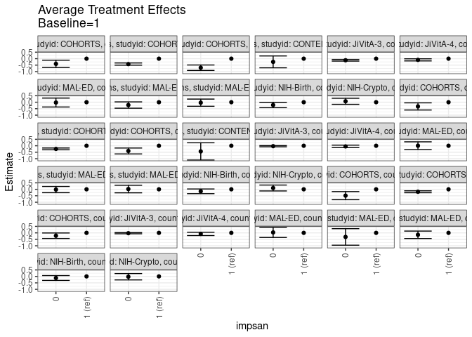

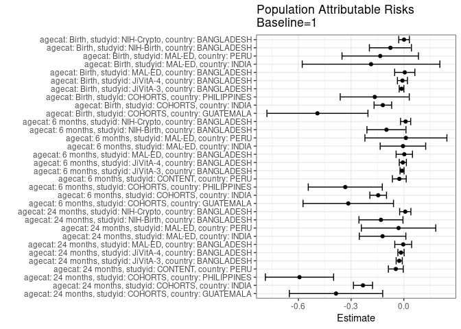

## Results Table

### Parameter: TSM

| agecat | studyid | country | intervention_level | baseline_level | estimate | ci_lower | ci_upper |
| --- | --- | --- | --- | --- | --- | --- | --- |
| Birth | COHORTS | GUATEMALA | 1 | NA | 0.4639502 | 0.1730640 | 0.7548363 |
| Birth | COHORTS | GUATEMALA | 0 | NA | -0.0250760 | -0.1410845 | 0.0909324 |
| Birth | COHORTS | INDIA | 1 | NA | -0.5583157 | -0.6184121 | -0.4982194 |
| Birth | COHORTS | INDIA | 0 | NA | -0.7475569 | -0.7898039 | -0.7053099 |
| Birth | COHORTS | PHILIPPINES | 1 | NA | -0.1482409 | -0.3480519 | 0.0515700 |
| Birth | COHORTS | PHILIPPINES | 0 | NA | -0.3692644 | -0.4402856 | -0.2982432 |
| Birth | JiVitA-3 | BANGLADESH | 1 | NA | -1.5768558 | -1.5996813 | -1.5540304 |
| Birth | JiVitA-3 | BANGLADESH | 0 | NA | -1.6037910 | -1.6442838 | -1.5632983 |
| Birth | JiVitA-4 | BANGLADESH | 1 | NA | -1.5155637 | -1.5733653 | -1.4577621 |
| Birth | JiVitA-4 | BANGLADESH | 0 | NA | -1.5980055 | -1.7111379 | -1.4848732 |
| Birth | MAL-ED | BANGLADESH | 1 | NA | -1.0583295 | -1.2084052 | -0.9082539 |
| Birth | MAL-ED | BANGLADESH | 0 | NA | -1.0244376 | -1.3854352 | -0.6634400 |
| Birth | MAL-ED | INDIA | 1 | NA | -0.9509816 | -1.4855489 | -0.4164144 |
| Birth | MAL-ED | INDIA | 0 | NA | -1.2660192 | -1.5990982 | -0.9329403 |
| Birth | MAL-ED | PERU | 1 | NA | -0.7788314 | -1.0293931 | -0.5282697 |
| Birth | MAL-ED | PERU | 0 | NA | -0.9284588 | -1.0682758 | -0.7886418 |
| Birth | NIH-Birth | BANGLADESH | 1 | NA | -0.8546012 | -1.0107161 | -0.6984863 |
| Birth | NIH-Birth | BANGLADESH | 0 | NA | -0.9784443 | -1.0862119 | -0.8706768 |
| Birth | NIH-Crypto | BANGLADESH | 1 | NA | -0.9142334 | -0.9893021 | -0.8391647 |
| Birth | NIH-Crypto | BANGLADESH | 0 | NA | -0.9409473 | -1.1764932 | -0.7054014 |
| 6 months | COHORTS | GUATEMALA | 1 | NA | -1.5627618 | -1.8255718 | -1.2999518 |
| 6 months | COHORTS | GUATEMALA | 0 | NA | -1.8895257 | -1.9777505 | -1.8013008 |
| 6 months | COHORTS | INDIA | 1 | NA | -0.8954786 | -0.9522305 | -0.8387267 |
| 6 months | COHORTS | INDIA | 0 | NA | -1.1386983 | -1.1804727 | -1.0969239 |
| 6 months | COHORTS | PHILIPPINES | 1 | NA | -0.8611166 | -1.0751016 | -0.6471315 |
| 6 months | COHORTS | PHILIPPINES | 0 | NA | -1.2644405 | -1.3379745 | -1.1909065 |
| 6 months | CONTENT | PERU | 1 | NA | -0.2527916 | -0.3875288 | -0.1180544 |
| 6 months | CONTENT | PERU | 0 | NA | -0.6902915 | -1.3454292 | -0.0351538 |
| 6 months | JiVitA-3 | BANGLADESH | 1 | NA | -1.3032248 | -1.3290475 | -1.2774020 |
| 6 months | JiVitA-3 | BANGLADESH | 0 | NA | -1.3359150 | -1.3825003 | -1.2893296 |
| 6 months | JiVitA-4 | BANGLADESH | 1 | NA | -1.3383103 | -1.3802449 | -1.2963757 |
| 6 months | JiVitA-4 | BANGLADESH | 0 | NA | -1.3876098 | -1.4762322 | -1.2989874 |
| 6 months | MAL-ED | BANGLADESH | 1 | NA | -1.2052654 | -1.3384944 | -1.0720365 |
| 6 months | MAL-ED | BANGLADESH | 0 | NA | -1.2006867 | -1.4679868 | -0.9333867 |
| 6 months | MAL-ED | INDIA | 1 | NA | -1.2036401 | -1.3719086 | -1.0353717 |
| 6 months | MAL-ED | INDIA | 0 | NA | -1.2245871 | -1.3955822 | -1.0535920 |
| 6 months | MAL-ED | PERU | 1 | NA | -1.3313278 | -1.5933113 | -1.0693444 |
| 6 months | MAL-ED | PERU | 0 | NA | -1.3113350 | -1.4376377 | -1.1850322 |
| 6 months | NIH-Birth | BANGLADESH | 1 | NA | -1.3084794 | -1.4486165 | -1.1683423 |
| 6 months | NIH-Birth | BANGLADESH | 0 | NA | -1.4640526 | -1.5787359 | -1.3493693 |
| 6 months | NIH-Crypto | BANGLADESH | 1 | NA | -1.2132590 | -1.2894434 | -1.1370745 |
| 6 months | NIH-Crypto | BANGLADESH | 0 | NA | -1.1125924 | -1.3262950 | -0.8988899 |
| 24 months | COHORTS | GUATEMALA | 1 | NA | -2.6192398 | -2.8908935 | -2.3475860 |
| 24 months | COHORTS | GUATEMALA | 0 | NA | -3.0216638 | -3.0961382 | -2.9471895 |
| 24 months | COHORTS | INDIA | 1 | NA | -1.9803070 | -2.0458096 | -1.9148045 |
| 24 months | COHORTS | INDIA | 0 | NA | -2.3981218 | -2.4519944 | -2.3442493 |
| 24 months | COHORTS | PHILIPPINES | 1 | NA | -2.0001108 | -2.1956940 | -1.8045276 |
| 24 months | COHORTS | PHILIPPINES | 0 | NA | -2.7002348 | -2.7788098 | -2.6216598 |
| 24 months | CONTENT | PERU | 1 | NA | -0.6411925 | -0.8001362 | -0.4822488 |
| 24 months | CONTENT | PERU | 0 | NA | -0.8902032 | -1.3207689 | -0.4596376 |
| 24 months | JiVitA-3 | BANGLADESH | 1 | NA | -1.9874152 | -2.0205389 | -1.9542915 |
| 24 months | JiVitA-3 | BANGLADESH | 0 | NA | -2.1104638 | -2.1723794 | -2.0485481 |
| 24 months | JiVitA-4 | BANGLADESH | 1 | NA | -1.7641675 | -1.8056033 | -1.7227316 |
| 24 months | JiVitA-4 | BANGLADESH | 0 | NA | -1.8575510 | -1.9308286 | -1.7842734 |
| 24 months | MAL-ED | BANGLADESH | 1 | NA | -1.9748238 | -2.1143002 | -1.8353474 |
| 24 months | MAL-ED | BANGLADESH | 0 | NA | -1.9995880 | -2.3160361 | -1.6831398 |
| 24 months | MAL-ED | INDIA | 1 | NA | -1.7569424 | -1.9254989 | -1.5883858 |
| 24 months | MAL-ED | INDIA | 0 | NA | -1.9765759 | -2.1558899 | -1.7972620 |
| 24 months | MAL-ED | PERU | 1 | NA | -1.7234358 | -1.9597393 | -1.4871323 |
| 24 months | MAL-ED | PERU | 0 | NA | -1.7599970 | -1.9040098 | -1.6159843 |
| 24 months | NIH-Birth | BANGLADESH | 1 | NA | -2.0888022 | -2.2564987 | -1.9211058 |
| 24 months | NIH-Birth | BANGLADESH | 0 | NA | -2.3046903 | -2.4305138 | -2.1788669 |
| 24 months | NIH-Crypto | BANGLADESH | 1 | NA | -1.4497764 | -1.5416853 | -1.3578675 |
| 24 months | NIH-Crypto | BANGLADESH | 0 | NA | -1.3788544 | -1.5952945 | -1.1624143 |

### Parameter: E(Y)

| agecat | studyid | country | intervention_level | baseline_level | estimate | ci_lower | ci_upper |
| --- | --- | --- | --- | --- | --- | --- | --- |
| Birth | COHORTS | GUATEMALA | NA | NA | -0.0275356 | -0.1359303 | 0.0808590 |
| Birth | COHORTS | INDIA | NA | NA | -0.6777115 | -0.7106054 | -0.6448175 |
| Birth | COHORTS | PHILIPPINES | NA | NA | -0.3137364 | -0.3764483 | -0.2510244 |
| Birth | JiVitA-3 | BANGLADESH | NA | NA | -1.5898288 | -1.6090823 | -1.5705753 |
| Birth | JiVitA-4 | BANGLADESH | NA | NA | -1.5236135 | -1.5727559 | -1.4744711 |
| Birth | MAL-ED | BANGLADESH | NA | NA | -1.0530516 | -1.1896058 | -0.9164975 |
| Birth | MAL-ED | INDIA | NA | NA | -1.1375000 | -1.4325178 | -0.8424822 |
| Birth | MAL-ED | PERU | NA | NA | -0.9131731 | -1.0331160 | -0.7932301 |
| Birth | NIH-Birth | BANGLADESH | NA | NA | -0.9310197 | -1.0197391 | -0.8423003 |
| Birth | NIH-Crypto | BANGLADESH | NA | NA | -0.9131068 | -0.9851939 | -0.8410197 |
| 6 months | COHORTS | GUATEMALA | NA | NA | -1.8789210 | -1.9609921 | -1.7968498 |
| 6 months | COHORTS | INDIA | NA | NA | -1.0414424 | -1.0741113 | -1.0087734 |
| 6 months | COHORTS | PHILIPPINES | NA | NA | -1.1942936 | -1.2608624 | -1.1277248 |
| 6 months | CONTENT | PERU | NA | NA | -0.2785256 | -0.4098735 | -0.1471776 |
| 6 months | JiVitA-3 | BANGLADESH | NA | NA | -1.3134804 | -1.3366079 | -1.2903528 |
| 6 months | JiVitA-4 | BANGLADESH | NA | NA | -1.3440477 | -1.3813060 | -1.3067894 |
| 6 months | MAL-ED | BANGLADESH | NA | NA | -1.2026806 | -1.3203025 | -1.0850586 |
| 6 months | MAL-ED | INDIA | NA | NA | -1.2087268 | -1.3282418 | -1.0892117 |
| 6 months | MAL-ED | PERU | NA | NA | -1.3196229 | -1.4293681 | -1.2098778 |
| 6 months | NIH-Birth | BANGLADESH | NA | NA | -1.4073821 | -1.4960598 | -1.3187043 |
| 6 months | NIH-Crypto | BANGLADESH | NA | NA | -1.2031037 | -1.2749632 | -1.1312442 |
| 24 months | COHORTS | GUATEMALA | NA | NA | -3.0050840 | -3.0758338 | -2.9343342 |
| 24 months | COHORTS | INDIA | NA | NA | -2.2126633 | -2.2518337 | -2.1734929 |
| 24 months | COHORTS | PHILIPPINES | NA | NA | -2.5937576 | -2.6629996 | -2.5245156 |
| 24 months | CONTENT | PERU | NA | NA | -0.6868598 | -0.8388476 | -0.5348719 |
| 24 months | JiVitA-3 | BANGLADESH | NA | NA | -2.0136975 | -2.0413718 | -1.9860232 |
| 24 months | JiVitA-4 | BANGLADESH | NA | NA | -1.7803708 | -1.8158650 | -1.7448765 |
| 24 months | MAL-ED | BANGLADESH | NA | NA | -1.9783962 | -2.1050210 | -1.8517715 |
| 24 months | MAL-ED | INDIA | NA | NA | -1.8779556 | -2.0033207 | -1.7525904 |
| 24 months | MAL-ED | PERU | NA | NA | -1.7535204 | -1.8760973 | -1.6309435 |
| 24 months | NIH-Birth | BANGLADESH | NA | NA | -2.2190579 | -2.3217459 | -2.1163699 |
| 24 months | NIH-Crypto | BANGLADESH | NA | NA | -1.4417097 | -1.5263855 | -1.3570340 |

### Parameter: ATE

| agecat | studyid | country | intervention_level | baseline_level | estimate | ci_lower | ci_upper |
| --- | --- | --- | --- | --- | --- | --- | --- |
| Birth | COHORTS | GUATEMALA | 1 | 1 | 0.0000000 | 0.0000000 | 0.0000000 |
| Birth | COHORTS | GUATEMALA | 0 | 1 | -0.4890262 | -0.8025548 | -0.1754975 |
| Birth | COHORTS | INDIA | 1 | 1 | 0.0000000 | 0.0000000 | 0.0000000 |
| Birth | COHORTS | INDIA | 0 | 1 | -0.1892412 | -0.2622379 | -0.1162445 |
| Birth | COHORTS | PHILIPPINES | 1 | 1 | 0.0000000 | 0.0000000 | 0.0000000 |
| Birth | COHORTS | PHILIPPINES | 0 | 1 | -0.2210234 | -0.4329721 | -0.0090747 |
| Birth | JiVitA-3 | BANGLADESH | 1 | 1 | 0.0000000 | 0.0000000 | 0.0000000 |
| Birth | JiVitA-3 | BANGLADESH | 0 | 1 | -0.0269352 | -0.0711590 | 0.0172886 |
| Birth | JiVitA-4 | BANGLADESH | 1 | 1 | 0.0000000 | 0.0000000 | 0.0000000 |
| Birth | JiVitA-4 | BANGLADESH | 0 | 1 | -0.0824418 | -0.2083429 | 0.0434592 |
| Birth | MAL-ED | BANGLADESH | 1 | 1 | 0.0000000 | 0.0000000 | 0.0000000 |
| Birth | MAL-ED | BANGLADESH | 0 | 1 | 0.0338919 | -0.3574785 | 0.4252623 |
| Birth | MAL-ED | INDIA | 1 | 1 | 0.0000000 | 0.0000000 | 0.0000000 |
| Birth | MAL-ED | INDIA | 0 | 1 | -0.3150376 | -0.9535137 | 0.3234385 |
| Birth | MAL-ED | PERU | 1 | 1 | 0.0000000 | 0.0000000 | 0.0000000 |
| Birth | MAL-ED | PERU | 0 | 1 | -0.1496274 | -0.4365564 | 0.1373017 |
| Birth | NIH-Birth | BANGLADESH | 1 | 1 | 0.0000000 | 0.0000000 | 0.0000000 |
| Birth | NIH-Birth | BANGLADESH | 0 | 1 | -0.1238431 | -0.3125906 | 0.0649043 |
| Birth | NIH-Crypto | BANGLADESH | 1 | 1 | 0.0000000 | 0.0000000 | 0.0000000 |
| Birth | NIH-Crypto | BANGLADESH | 0 | 1 | -0.0267139 | -0.2733853 | 0.2199574 |
| 6 months | COHORTS | GUATEMALA | 1 | 1 | 0.0000000 | 0.0000000 | 0.0000000 |
| 6 months | COHORTS | GUATEMALA | 0 | 1 | -0.3267638 | -0.6038798 | -0.0496478 |
| 6 months | COHORTS | INDIA | 1 | 1 | 0.0000000 | 0.0000000 | 0.0000000 |
| 6 months | COHORTS | INDIA | 0 | 1 | -0.2432197 | -0.3126262 | -0.1738132 |
| 6 months | COHORTS | PHILIPPINES | 1 | 1 | 0.0000000 | 0.0000000 | 0.0000000 |
| 6 months | COHORTS | PHILIPPINES | 0 | 1 | -0.4033239 | -0.6300719 | -0.1765759 |
| 6 months | CONTENT | PERU | 1 | 1 | 0.0000000 | 0.0000000 | 0.0000000 |
| 6 months | CONTENT | PERU | 0 | 1 | -0.4374998 | -1.1060654 | 0.2310657 |
| 6 months | JiVitA-3 | BANGLADESH | 1 | 1 | 0.0000000 | 0.0000000 | 0.0000000 |
| 6 months | JiVitA-3 | BANGLADESH | 0 | 1 | -0.0326902 | -0.0793053 | 0.0139249 |
| 6 months | JiVitA-4 | BANGLADESH | 1 | 1 | 0.0000000 | 0.0000000 | 0.0000000 |
| 6 months | JiVitA-4 | BANGLADESH | 0 | 1 | -0.0492994 | -0.1474387 | 0.0488398 |
| 6 months | MAL-ED | BANGLADESH | 1 | 1 | 0.0000000 | 0.0000000 | 0.0000000 |
| 6 months | MAL-ED | BANGLADESH | 0 | 1 | 0.0045787 | -0.2953808 | 0.3045382 |
| 6 months | MAL-ED | INDIA | 1 | 1 | 0.0000000 | 0.0000000 | 0.0000000 |
| 6 months | MAL-ED | INDIA | 0 | 1 | -0.0209469 | -0.2615742 | 0.2196803 |
| 6 months | MAL-ED | PERU | 1 | 1 | 0.0000000 | 0.0000000 | 0.0000000 |
| 6 months | MAL-ED | PERU | 0 | 1 | 0.0199929 | -0.2714053 | 0.3113911 |
| 6 months | NIH-Birth | BANGLADESH | 1 | 1 | 0.0000000 | 0.0000000 | 0.0000000 |
| 6 months | NIH-Birth | BANGLADESH | 0 | 1 | -0.1555731 | -0.3354475 | 0.0243013 |
| 6 months | NIH-Crypto | BANGLADESH | 1 | 1 | 0.0000000 | 0.0000000 | 0.0000000 |
| 6 months | NIH-Crypto | BANGLADESH | 0 | 1 | 0.1006665 | -0.1267758 | 0.3281089 |
| 24 months | COHORTS | GUATEMALA | 1 | 1 | 0.0000000 | 0.0000000 | 0.0000000 |
| 24 months | COHORTS | GUATEMALA | 0 | 1 | -0.4024241 | -0.6840878 | -0.1207603 |
| 24 months | COHORTS | INDIA | 1 | 1 | 0.0000000 | 0.0000000 | 0.0000000 |
| 24 months | COHORTS | INDIA | 0 | 1 | -0.4178148 | -0.5028490 | -0.3327806 |
| 24 months | COHORTS | PHILIPPINES | 1 | 1 | 0.0000000 | 0.0000000 | 0.0000000 |
| 24 months | COHORTS | PHILIPPINES | 0 | 1 | -0.7001240 | -0.9114548 | -0.4887932 |
| 24 months | CONTENT | PERU | 1 | 1 | 0.0000000 | 0.0000000 | 0.0000000 |
| 24 months | CONTENT | PERU | 0 | 1 | -0.2490107 | -0.7072317 | 0.2092102 |
| 24 months | JiVitA-3 | BANGLADESH | 1 | 1 | 0.0000000 | 0.0000000 | 0.0000000 |
| 24 months | JiVitA-3 | BANGLADESH | 0 | 1 | -0.1230486 | -0.1872029 | -0.0588943 |
| 24 months | JiVitA-4 | BANGLADESH | 1 | 1 | 0.0000000 | 0.0000000 | 0.0000000 |
| 24 months | JiVitA-4 | BANGLADESH | 0 | 1 | -0.0933835 | -0.1747380 | -0.0120291 |
| 24 months | MAL-ED | BANGLADESH | 1 | 1 | 0.0000000 | 0.0000000 | 0.0000000 |
| 24 months | MAL-ED | BANGLADESH | 0 | 1 | -0.0247642 | -0.3706072 | 0.3210789 |
| 24 months | MAL-ED | INDIA | 1 | 1 | 0.0000000 | 0.0000000 | 0.0000000 |
| 24 months | MAL-ED | INDIA | 0 | 1 | -0.2196336 | -0.4637558 | 0.0244886 |
| 24 months | MAL-ED | PERU | 1 | 1 | 0.0000000 | 0.0000000 | 0.0000000 |
| 24 months | MAL-ED | PERU | 0 | 1 | -0.0365613 | -0.3144323 | 0.2413098 |
| 24 months | NIH-Birth | BANGLADESH | 1 | 1 | 0.0000000 | 0.0000000 | 0.0000000 |
| 24 months | NIH-Birth | BANGLADESH | 0 | 1 | -0.2158881 | -0.4236394 | -0.0081368 |
| 24 months | NIH-Crypto | BANGLADESH | 1 | 1 | 0.0000000 | 0.0000000 | 0.0000000 |
| 24 months | NIH-Crypto | BANGLADESH | 0 | 1 | 0.0709220 | -0.1639953 | 0.3058393 |

### Parameter: PAR

| agecat | studyid | country | intervention_level | baseline_level | estimate | ci_lower | ci_upper |
| --- | --- | --- | --- | --- | --- | --- | --- |
| Birth | COHORTS | GUATEMALA | 1 | NA | -0.4914858 | -0.7788139 | -0.2041577 |
| Birth | COHORTS | INDIA | 1 | NA | -0.1193957 | -0.1694085 | -0.0693830 |
| Birth | COHORTS | PHILIPPINES | 1 | NA | -0.1654954 | -0.3619065 | 0.0309157 |
| Birth | JiVitA-3 | BANGLADESH | 1 | NA | -0.0129730 | -0.0262250 | 0.0002791 |
| Birth | JiVitA-4 | BANGLADESH | 1 | NA | -0.0080498 | -0.0365567 | 0.0204572 |
| Birth | MAL-ED | BANGLADESH | 1 | NA | 0.0052779 | -0.0522119 | 0.0627677 |
| Birth | MAL-ED | INDIA | 1 | NA | -0.1865184 | -0.5780278 | 0.2049911 |
| Birth | MAL-ED | PERU | 1 | NA | -0.1343417 | -0.3517453 | 0.0830620 |
| Birth | NIH-Birth | BANGLADESH | 1 | NA | -0.0764186 | -0.1959383 | 0.0431012 |
| Birth | NIH-Crypto | BANGLADESH | 1 | NA | 0.0011266 | -0.0291624 | 0.0314156 |
| 6 months | COHORTS | GUATEMALA | 1 | NA | -0.3161591 | -0.5734755 | -0.0588427 |
| 6 months | COHORTS | INDIA | 1 | NA | -0.1459638 | -0.1934765 | -0.0984511 |
| 6 months | COHORTS | PHILIPPINES | 1 | NA | -0.3331770 | -0.5437803 | -0.1225738 |
| 6 months | CONTENT | PERU | 1 | NA | -0.0257340 | -0.0649587 | 0.0134908 |
| 6 months | JiVitA-3 | BANGLADESH | 1 | NA | -0.0102556 | -0.0217606 | 0.0012494 |
| 6 months | JiVitA-4 | BANGLADESH | 1 | NA | -0.0057373 | -0.0259230 | 0.0144483 |
| 6 months | MAL-ED | BANGLADESH | 1 | NA | 0.0025849 | -0.0439936 | 0.0491633 |
| 6 months | MAL-ED | INDIA | 1 | NA | -0.0050866 | -0.1344828 | 0.1243096 |
| 6 months | MAL-ED | PERU | 1 | NA | 0.0117049 | -0.2215817 | 0.2449915 |
| 6 months | NIH-Birth | BANGLADESH | 1 | NA | -0.0989026 | -0.2099515 | 0.0121462 |
| 6 months | NIH-Crypto | BANGLADESH | 1 | NA | 0.0101553 | -0.0187143 | 0.0390248 |
| 24 months | COHORTS | GUATEMALA | 1 | NA | -0.3858442 | -0.6514808 | -0.1202077 |
| 24 months | COHORTS | INDIA | 1 | NA | -0.2323562 | -0.2867039 | -0.1780086 |
| 24 months | COHORTS | PHILIPPINES | 1 | NA | -0.5936468 | -0.7879567 | -0.3993369 |
| 24 months | CONTENT | PERU | 1 | NA | -0.0456672 | -0.0879874 | -0.0033471 |
| 24 months | JiVitA-3 | BANGLADESH | 1 | NA | -0.0262823 | -0.0437249 | -0.0088398 |
| 24 months | JiVitA-4 | BANGLADESH | 1 | NA | -0.0162033 | -0.0338891 | 0.0014825 |
| 24 months | MAL-ED | BANGLADESH | 1 | NA | -0.0035724 | -0.0514728 | 0.0443279 |
| 24 months | MAL-ED | INDIA | 1 | NA | -0.1210132 | -0.2535020 | 0.0114756 |
| 24 months | MAL-ED | PERU | 1 | NA | -0.0300846 | -0.2418114 | 0.1816422 |
| 24 months | NIH-Birth | BANGLADESH | 1 | NA | -0.1302557 | -0.2554487 | -0.0050626 |
| 24 months | NIH-Crypto | BANGLADESH | 1 | NA | 0.0080667 | -0.0238958 | 0.0400292 |